# BA_HW2

Sumanth

11/7/2019

1. Run the following code in R-studio to create two variables X and Y. set.seed(2017) X=runif(100)*10 Y=X*4+3.45 Y=rnorm(100)*0.29*Y+Y

```r
set.seed(2017)
X=runif(100)*10
Y=X*4+3.45
Y=rnorm(100)*0.29*Y+Y
```

1. Plot Y against X. Include a screenshot of the plot in your submission. Using the File menu you can save the graph as a picture on your computer. Based on the plot do you think we can fit a linear model to explain Y based on X? (5 Marks)

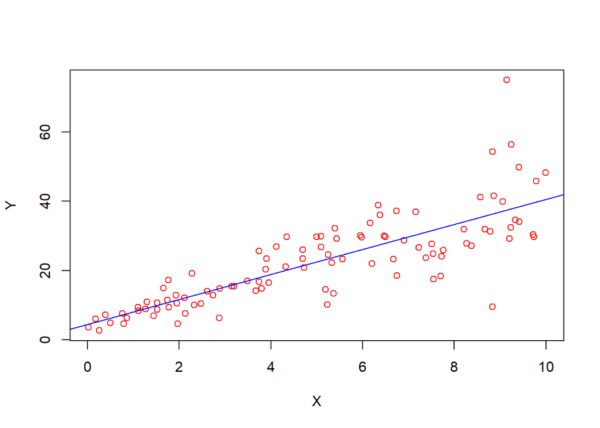

```r
plot(Y~X,xlab='X',ylab='Y',col='red')
abline(lsfit(X, Y),col = "blue")
```

2. Construct a simple linear model of Y based on X. Write the equation that explains Y based on X. What is the accuracy of this model? (5 Marks)

Y=4.4655+3.6108*X Accuracy is 0.6517 or 65%

```r
fit <- lm(Y ~ X)
summary(fit)
```

```
##
## Call:
## lm(formula = Y ~ X)
##
## Residuals:
##     Min      1Q  Median      3Q     Max
## -26.755  -3.846  -0.387   4.318  37.503
##
## Coefficients:
##             Estimate Std. Error t value Pr(>|t|)
## (Intercept)   4.4655     1.5537   2.874  0.00497 **
## X             3.6108     0.2666  13.542  < 2e-16 ***
## ---
## Signif. codes:  0 '***' 0.001 '**' 0.01 '*' 0.05 '.' 0.1 ' ' 1
##
## Residual standard error: 7.756 on 98 degrees of freedom
## Multiple R-squared:  0.6517, Adjusted R-squared:  0.6482
## F-statistic: 183.4 on 1 and 98 DF,  p-value: < 2.2e-16
```

3. How the Coefficient of Determination, R2, of the model above is related to the correlation coefficient of X and Y? (5 marks)

```r
cor(X,Y)^2
```

```
## [1] 0.6517187
```

Solution: The square of correlation coefficient is same as coefficient of determination 65.17% #Coefficient of Determination= (Correlation Coefficient)2

4. Investigate the appropriateness of using linear regression for this case (10 Marks). You may also find the story here relevant. More useful hints: #residual analysis, #pattern of residuals, #normality of residuals.

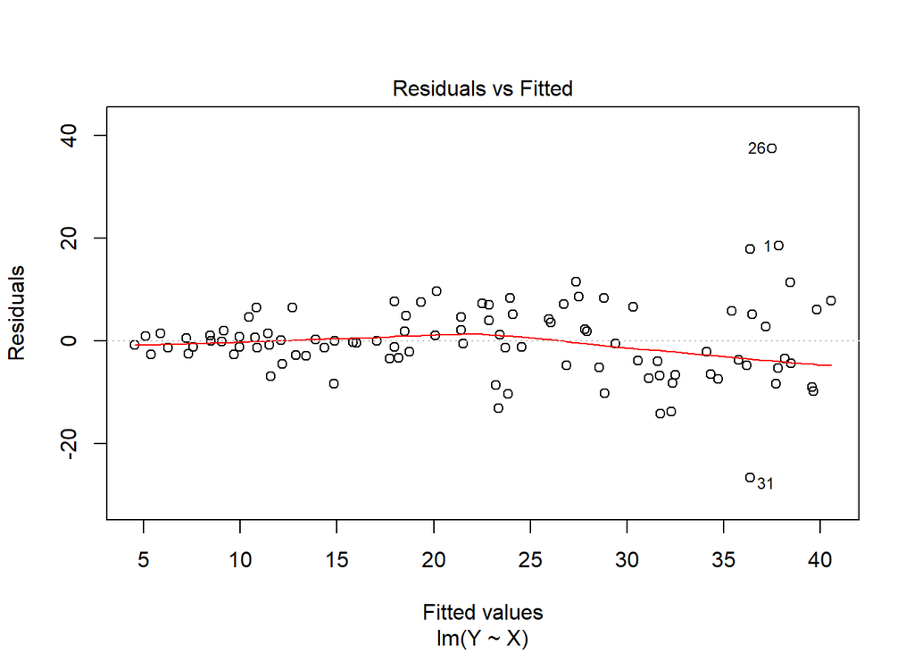

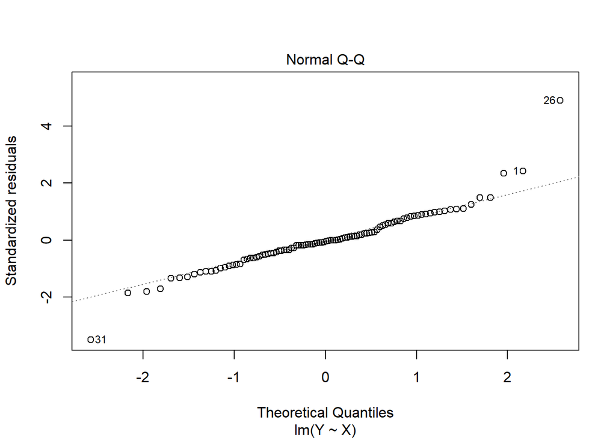

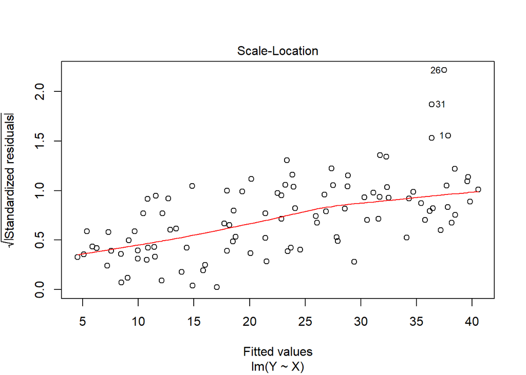

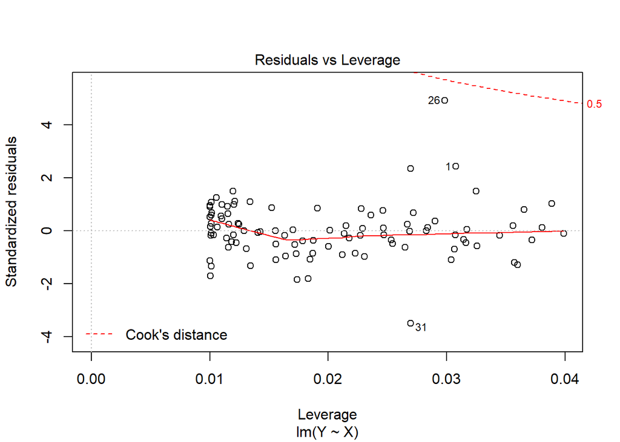

```r
plot(fit)
```